# DAPT Numerical Solution

Shawn Garbett

18 July, 2017

# Introduction

Solution of the Dual Anti-platelet Therapy (DAPT) model in a fast format is required for delivery of AIM III of the RIGHT grant. The DAPT model is an economic model for costs and quality of life under various drug treatments for DAPT. AIM III requires a probability sensitivity analysis for the model versus known parameters. This report details the method of the solution in R.

The code will be translated into Julia for quick model execution over a defined parameter space for final probability sensitivity analysis.

There are various drugs available with different rates of side effects, and differing severity of side effects. These side effects are further determined by genetic predispositions, and the DAPT model will be incorporated into a larger model that involves decision making about treatment based upon genomic information. Solution of costs for a population undergoing a specific treatment with the same genetic make up is required first before higher level composition is performed.

## Model requirements

This DAPT modeling effort is based primarily upon Kazi et al. (2014). Further refinement based upon observations from Vanderbilt’s electronic medical record are used to anchor the population under study. In additional secular death rates are taken from social security public data.

- The model studies a population in time ($t$) from the establishment of a medical home.
  - Time will be measured in years.
  - The time horizon considered here is 10 years.
  - The time to beginning DAPT therapy is described by a Weibull model. See Yaping’s report.
- Once therapy begins, the age ($a$) of therapy determines event rates. These are categorized by 3 phases.
  - Phase 1: The first 30 days have a specific set of risks.
  - Phase 2: The 31-365th day have a specific set of risks.
  - Phase 3: Years 2+ have a specific set of risks.
- There is a treatment naive compartment.
- There is a primary treatment compartment.
  - Primary treatment lasts one year.
  - Primary treatment can be aborted when a coronary artery bypass grafting (CABG) event occurs, and the patient will undergo maintenance treatment.
  - Primary treatment can be restarted up 5 times when a percutaneous coronary intervention (PCI) event occurs.
  - A 6th PCI event is treated as a CABG.
  - Fatal events can occur which abort treatment.
- There is a maintenance treatment compartment.
  - Maintenance last to end of model.
  - CABG events can still occur, but patient remains in maintenance therapy..
  - PCI events can still occur, but patient remains in maintenance therapy.
  - Fatal events can occur which abort treatment.
- There is a fatality compartment for treatment fatalities.
- Fatality from external secular death will occur as given by social security data.
- For each compartment there is a cost in dollars for treatment over time.
  - Part of the cost is yearly drug cost.
  - Adverse events also contribute to yearly cost to be on primary or maintenance treatment.
  - Cost is discounted by time in model.
- For each compartment there is a decrement in quality adjusted life years (QALY) for treatment over time.
  - Fatal compartments have zero QALY.
  - QALY decrements can be temporary, and as such are applied as daily averages.
  - QALY decrements from events can be permanent.
  - QALY is discounted by time in model as well.

## Specification

This model is represented by an age-structured model, i.e. one that has the related dimensions of age of therapy ($a$) and time ($t$). While patients are beginning therapy at different times in the model, the aging of therapy proceeds along what is called a characteristic line where $a+t=c$. Since each patients progression is independent, partial differential equations are not required and one can solve along these characteristic lines, see Webb (2008).

We will refer to the 1st primary treatment compartment as $f(t,a)$ and use 1 to represent 100% of the population and 0 to represent 0% of the population and track occupancy through the model. Some boundary conditions become obvious $f(t,a)=0$ for $t<0$ as well as $f(t,a)=0$ for $a>t$ which creates a triangular space. Since primary therapy cannot continue past the first year we also have $f(t,a)=0$ for $a>1$. Further, the entry rate into the model along the $f(t,0)$ boundary is given by a Weibull distribution as mentioned above, i.e. $f(t, 0) = w(t\mid\lambda, k)$ where $w$ represent the Weibull probability density function where $\lambda$ is the scale and $k$ is the shape.

We will further represent the maintenance compartment of post primary therapy by $g(t,a)$. This compartment is those who completed primary therapy with no special events, i.e. PCI, CABG or treatment fatality.

Secular death is a function of time ($t$) alone and will be represented as $s(t)$. It is independent of any other model effects or phases and can be separated out. Inside the boundaries the solution can be achieved using separability $f(t,a) = s(t) w(t-a) f(a)$, and likewise for $g(t,a)$. Thus two equations represent the cornerstone of the solution. From these we can now create a series of coupled first order delay differential equation’s using compartments for each phase of PCI restarts of primary therapy, and CABG joining maintenance. With the solution of this in hand, the final stage is to turn it into a time ($t$) only model by integrating out the age dimension $f(t)= \int^{t_H}_{0} f(t,a) da = s(t) \int^{t_H}_{0} w(t-a) f(a) da$ where $t_H$ represents the time horizon of the model.

From these time $t$ based solutions we can proceed forward to integrate costs and QALY for the final total cost and QALY given the risks and cost specification.

## Parameter Key

Subscripts of ‘p’ denote primary treatment and ‘m’ maintenance treatment.

Subscripts of 1, 2, or 3 denote age phase of treatment.

| symbol | meaning |
| --- | --- |
| $\chi$ | Cost per unit time: $\chi_{p1},\chi_{p2},\chi_{p3},\chi_{m1},\chi_{m2},\chi_{m3}$ |
| $\delta$ | Discount rate |
| $f(t,a), f(t), f(a)$ | 1st Primary treatment functions |
| $g(a)$ | Maintenance treatment (no CABG/PCI) |
| $i$ | Risk phase due to age of therapy (1,2, or 3) |
| $j$ | Risk phase 1 year ago |
| $k$ | Weibull shape |
| $\kappa$ | CABG rates: $\kappa_{p1},\kappa_{p2},\kappa_{p3},\kappa_{m1},\kappa_{m2},\kappa_{m3}$ |
| $\lambda$ | Weibull scale |
| $m(a)$ | Maintence treatment from CABG |
| $p_n(a)$ | *n*th PCI primary treatment |
| $\phi$ | fatality rates: $\phi_{p1},\phi_{p2},\phi_{p3},\phi_{m1},\phi_{m2},\phi_{m3}$ |
| $\pi$ | PCI rates: $\pi_{p1},\pi_{p2},\pi_{p3},\pi_{m1},\pi_{m2},\pi_{m3}$ |
| $\psi$ | QALY permanent loss per event: $\psi_{p1},\psi_{p2},\psi_{p3},\psi_{m1},\psi_{m2},\psi_{m3}$ |
| $\rho$ | QALY penalty per unit time: $\rho_{p1},\rho_{p2},\rho_{p3},\rho_{m1},\rho_{m2},\rho_{m3}$ |
| $w(t\mid\lambda, k)$ | Weibull pdf for time to treatment |
| $W(t\mid\lambda, k)$ | Weibull cdf for time to treatment |
| $\zeta(a)$ | Exposure to loss in initial treatment compartment for last year |

## Cornerstone Equations

$f(a)$ represents those in initial primary treatment. Since drop out rates are exponential, and determined by rates of CABG, PCI and fatality, a piece wise solution is possible.

$$f(a) = \begin{cases}
0, & a < 0 \\
e^{-(\phi_{p1}+\kappa_{p1}+\pi_{p1} )a}, & a \le \frac{30}{365} \\
e^{-(\phi_{p1}+\kappa_{p1}+\pi_{p1} )30/365}e^{-(\phi_{p2}+\kappa_{p2}+\pi_{p2} )a}, & \frac{30}{365} \lt a \le 1 \\
0, & a \gt 1 \\
\end{cases}$$

Similarly $g(a)$ representing those in maintenance therapy who completed initial without incident is obtainable. Except loss from maintenance is only due to fatalities

$$g(a) = \begin{cases}
0, & a \le 1 \\
f(1) e^{-\phi_{m3}a}, & a \gt 1 \\
\end{cases}$$
$g(a)$ is defined in terms of the boundary of $f(a)$. The solution is defined relative to the equations. In the later coding a numerical solution it is sometimes useful to compute $f(a)$ outside of it’s boundaries due to these relationships.

## DDE Definition

The most difficult part of the definition is now the PCI primary treatment compartments, $p_n(a)$. Using the subscript $i$ to denote current therapy phase and $j$ to denote therapy phase from a year ago. Each of these $p_n$ needs to add occupants based on upstream compartment and current rate of PCI. Further they need to remove those that occur in the current compartment. Losses from CABG and fatalities are removed based on current occupancy. Finally, the delay portion removes the portion who entered a year ago from the compartment adjusted by exposure to losses, $\zeta(a)$.

$$\begin{align*}
\frac{d}{da} m &= \kappa_{pi}(f(a)+p_1+p_2+p_3+p_4+p_5)+\pi_{pi} p_5 \\
\frac{d}{da} p_1 &= \pi_{pi}(f(a) - p_1) - (\phi_{pi}+\kappa_{pi}) p_1 - \pi_{pj} f(a-1) \zeta(a) \\
\frac{d}{da} p_2 &= \pi_{pi}(p_1 - p_2) - (\phi_{pi}+\kappa_{pi}) p_2 - \pi_{pj} p_1(a-1) \zeta(a) \\
\frac{d}{da} p_3 &= \pi_{pi}(p_2 - p_3) - (\phi_{pi}+\kappa_{pi}) p_3 - \pi_{pj} p_2(a-1) \zeta(a) \\
\frac{d}{da} p_4 &= \pi_{pi}(p_3 - p_4) - (\phi_{pi}+\kappa_{pi}) p_4 - \pi_{pj} p_3(a-1) \zeta(a) \\
\frac{d}{da} p_5 &= \pi_{pi}(p_4 - p_5) - (\phi_{pi}+\kappa_{pi}) p_5 - \pi_{pj} p_4(a-1) \zeta(a) \\ \\
\text{primary}(a) &= f(a) + p_1 + p_2 + p_3 + p_4 + p_5 \\
\text{maint}(a) &= g(a) + m \\
\frac{d}{da} \text{fatalities} &= \phi_{pi}\text{primary(a)} + \phi_{mi}\text{maint(a)} \\
\end{align*}$$

# Working Solution in R

A specification of relevant parameter follows. Vectors of 3 entries represent the 3 phases of risk. For demonstration these are set randomly.

```r
set.seed(15)
params <- list(
# Costs / QALY discounting rate
  discount = 0.03,

# Weibull entry rate to treatment from healthy population
  shape = 0.59,
  scale = 60475.53,

# phi is fatality rate
# p is primary treatment, m is maintenance treatment compartment
# 1 is first 30 days, 2 is first year, 3 is 1+ year compartment
  phi_p = rnorm(3, 0.1, 0.025),
  phi_m = rnorm(3, 0.1, 0.025),
# kappa for CABG rates, aka fall out of primary to maintenence
  kappa_p = rnorm(3, 0.1, 0.025),
  kappa_m = rnorm(3, 0.1, 0.025),

# pi for PCI rate, i.e. restarting primary treatment rate
  pi_p = rnorm(3, 0.1, 0.025),
  pi_m = rnorm(3, 0.1, 0.025),

# Chi Daily costs for each compartment
  chi_p = rnorm(3, 0.1, 0.025),
  chi_m = rnorm(3, 0.1, 0.025),
# rho daily QALY penalty
  rho_p = rnorm(3, 0.1, 0.025),
  rho_m = rnorm(3, 0.1, 0.025),
# psi permanent QALY penalty
  psi_p = rnorm(3, 0.1, 0.025),
  psi_m = rnorm(3, 0.1, 0.025)
)
```

Some derived rates are helpful. `f_loss` is representative of all losses, fatality, CABG and PCI from the initial primary treatment. `g_loss` is a continuation of `f_loss` but with only fatality losses in phase three. This provides convent computation of $g(a)$ as a continuation of $f(a)$ but is only evaluated inside $g(a)$’s boundaries, i.e. $a>=1$.

```r
# Primary loss from f due to PCI, CABG and fatality
params$f_loss    <- with(params, {phi_p + kappa_p + pi_p})
params$g_loss    <- params$f_loss
params$g_loss[3] <- params$phi_m[3]
```

A fencing function helps in clipping values to hard boundaries.

```r
fence <- function(x, lb, ub) pmax(lb, pmin(x, ub))
```

Definition of Weibull and Secular death functions. A definition of healthy treatment naive population is simple.

```r
# Weibull functions with boundaries built in
# Only valid for t > 0
w <- function(t, params) dweibull(t, params$shape, params$scale/365)
W <- function(t, params) pweibull(t, params$shape, params$scale/365)
# Death as ratio of whole at time t in years
# Estimated by convolution of arrival age distribution in Vanderbilt
# population with SS secular death rates
# Only valid for 10 years in present formulation
s <- function(t) exp(0.01272623*(1-exp(0.0940359*t))/0.0940359)
# Survival of healthy treatment naive individual population, t in years
lambda <- function(t, params) s(t) * (1 - W(t, params))
```

The cornerstone equations is a piece wise exponential loss functions with a rate specified for each phase.

```r
# Loss in each phase via piecewise exponential
loss <- Vectorize(vectorize.args="a", FUN=function(a, rates)
{
  prod(exp(c(-fence(a,        0,  30/365),
             -fence(a-30/365, 0, 335/365),
             -fence(a-1,      0, Inf    ))*rates))
})
```

Similar to the `loss` definition a total loss exposure for the last year, $a-1$, is necessary in specifying part of the delay relationship in the delay differential. This uses the range $(a-1, a)$ and clips to current phase boundaries to compute exposure.

```r
# Exposure
exposed <- function(a, rates)
{
  left  <- max(a-1, 0)
  mon   <- 30/365
  sum(
    c(if(left > 30/365) 0 else min(mon, a) - left,
      if(left <= 1 && a >= mon) min(1, a) - max(30/365, left) else 0,
      if(a < 1) 0 else a - max(1, left)
    )*rates
  )
}
```

Now for the delay differential equation with all compartments to solve the age equations.

```r
library(deSolve)
clopidogrel <- function(a, y, params)
{
  with(as.list(c(y,params)), {
    # Risk phase determined from therapy age (a)
    i <- if(a <= 30/365) 1 else
         if(a <= 1)      2 else
                         3

    # Forcing function for primary compartment (f -> g)
    # Corner stone equations for f(a), g(a)
    f   <- loss(a, f_loss)
    f_a <- if(a > 1) 0 else f
    g_a <- if(a > 1) loss(a, g_loss) else 0

    # Compute PCI completion, i.e. how many entered a year ago minus loss
    exposure <- exp(-exposed(a, f_loss))
    cp_1 <- if(a < 1) 0 else lagderiv(a-1,  8)*exposure
    cp_2 <- if(a < 1) 0 else lagderiv(a-1,  9)*exposure
    cp_3 <- if(a < 1) 0 else lagderiv(a-1, 10)*exposure
    cp_4 <- if(a < 1) 0 else lagderiv(a-1, 11)*exposure
    cp_5 <- if(a < 1) 0 else lagderiv(a-1, 12)*exposure

    # The rate of inbound CABG from initial treatment and all PCI compartments
    cabg_r <- kappa_p[i]*(f_a + pci_1 + pci_2 + pci_3 + pci_4 + pci_5)+pi_p[i]*pci_5
    list(c(
      # maintenance from CABG
      m     = cabg_r + cp_1 + cp_2 + cp_3 + cp_4 + cp_5 - phi_m[i]*m,
      # total CABG events
      cabg  = cabg_r + kappa_m[i]*(m+g_a),
      # PCI restart compartments
      pci_1 = pi_p[i]*(f_a   - pci_1) - phi_p[i]*pci_1 - kappa_p[i]*pci_1 - cp_1,
      pci_2 = pi_p[i]*(pci_1 - pci_2) - phi_p[i]*pci_2 - kappa_p[i]*pci_2 - cp_2,
      pci_3 = pi_p[i]*(pci_2 - pci_3) - phi_p[i]*pci_3 - kappa_p[i]*pci_3 - cp_3,
      pci_4 = pi_p[i]*(pci_3 - pci_4) - phi_p[i]*pci_4 - kappa_p[i]*pci_4 - cp_4,
      pci_5 = pi_p[i]*(pci_4 - pci_5) - phi_p[i]*pci_5 - kappa_p[i]*pci_5 - cp_5,
      # Bookkeeping on PCI compartment entry rates (used by lagderiv)
      pn_1  = pi_p[i]*f_a,
      pn_2  = pi_p[i]*pci_1,
      pn_3  = pi_p[i]*pci_2,
      pn_4  = pi_p[i]*pci_3,
      pn_5  = pi_p[i]*pci_4,
      # Fatalities from primary and maintence treatement
      ftl_p = phi_p[i]*(f_a + pci_1 + pci_2 + pci_3 + pci_4 + pci_5),
      ftl_m = phi_m[i]*(g_a + m),
      # Total PCI events
      pci_t = pn_1+pn_2+pn_3+pn_4+pn_5+pi_m[i]*(g_a+m),
      # Discounting rate for convenience
      disc  = -discount*disc
      ),
      # Initial treatment compartment
      f     = f_a,
      # Those that complete initial treatment and continue to maintenance
      g     = g_a,
      # A total of all those receiving primary treatment
      prime = f_a + pci_1 + pci_2 + pci_3 + pci_4 + pci_5,
      # A total of all those on maintenance treatment
      maint = g_a + m,
      # A total of all those fatalities from treatment
      fatal = ftl_p + ftl_m
    )
  })
}
# Mostly zeros, input is from f(a)
yinit <- c(    m=0,  cabg=0,
           pci_1=0, pci_2=0, pci_3=0, pci_4=0, pci_5=0,
            pn_1=0,  pn_2=0,  pn_3=0,  pn_4=0,  pn_5=0,
           ftl_p=0, ftl_m=0, pci_t=0,
            disc=1
          )
ages  <- seq(0, 10, by=1/365)
system.time(out <- dede(yinit, ages, clopidogrel, params, atol=1e-9))
```

```
   user  system elapsed
  7.672   0.012   7.672
```

The final plots of where the population is all those receiving treatment plotted along age of therapy are of interest. Note this is a random set of parameters and does not reflect a specific primary treatment such as Clopidogrel.

```r
par(mfrow=c(2,2))
plot(out[,1], 100*out[,"prime"], main='Primary Treatment',
     typ='l', xlab='a', ylab='%pop', ylim=c(0,100))
plot(out[,1], 100*out[,"maint"], main='Maintenance Treatment',
     typ='l', xlab='a', ylab='%pop', ylim=c(0,100))
```

```r
plot(out[,1], 100*out[,"fatal"], main='Treatment Fatalities',
     typ='l', xlab='a', ylab='%pop', ylim=c(0,100))
plot(out[,1], out[,"pci_t"], main='PCI Restarts',
     typ='l', xlab='a', ylab='Count')
```

[figure not shown]

```r
par(mfrow=c(1,1))
```

### Numerical Accuracy

Any numerical method is subject to accumulating round off errors and as such it is important to validate that the solution’s accuracy is provided within the necessary tolerance. In this model, the the age solutions should account for 100% of the population in that an individual is neither created or destroyed. Using this property one can compute the total variation over time where fractions of the population are lost or gained. Current discrete event simulations of the DAPT model require 10,000,000 individuals to achieve 5 digits of accuracy with respect to true value. It is desirable to have around 8 digits of accuracy.

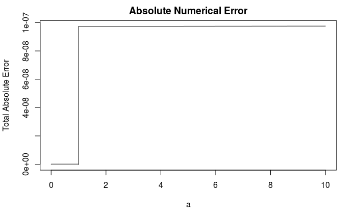

```r
plot(out[,1], out[,"prime"] + out[,"maint"] + out[,"fatal"] - 1,
     main="Absolute Numerical Error",
     typ='l', xlab='a', ylab="Total Absolute Error")
```

## Time Domain Transform

Now the final transform to time based solution and elimination of the age variable can be done as mentioned via the earlier separation.

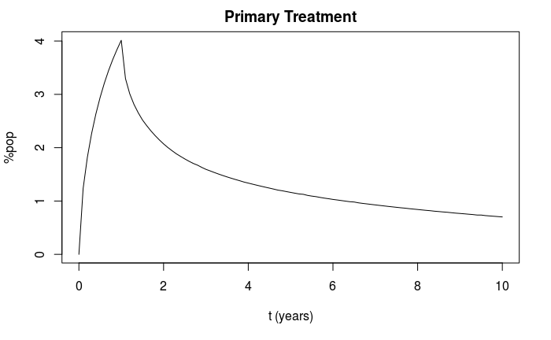

```r
sf_a <- splinefun(out[,1], out[,"prime"], method="fmm")
f_t <- Vectorize(function(t) s(t)*integrate(function(a) ifelse(t-a <= 0, 0,w(t-a, params))*sf_a(a), lower=0, upper=t)$value)
curve(100*f_t(x), from=0, to=10, ylab="%pop", xlab="t (years)", main="Primary Treatment")
```

Note the shark fin shape. This is exactly the shape we see from simulation runs.

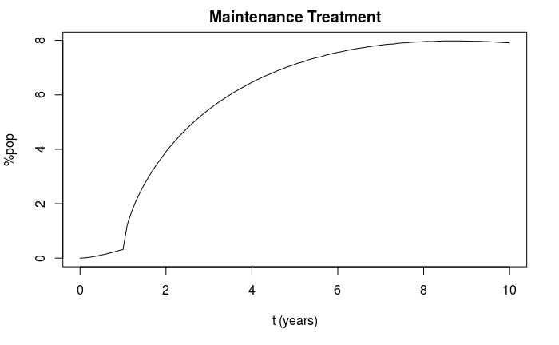

```r
sm_a <- splinefun(out[,1], out[,"maint"], method="fmm")
m_t <- Vectorize(function(t) s(t)*integrate(function(a) ifelse(t-a <= 0, 0,w(t-a, params))*sm_a(a), lower=0, upper=t)$value)
curve(100*m_t(x), from=0, to=10, ylab="%pop", xlab="t (years)", main="Maintenance Treatment")
```

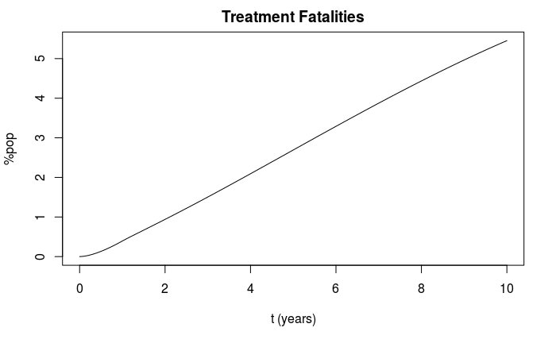

```r
sd_a <- splinefun(out[,1], out[,"fatal"], method="fmm")
d_t <- Vectorize(function(t) s(t)*integrate(function(a) ifelse(t-a <= 0, 0,w(t-a, params))*sd_a(a), lower=0, upper=t)$value)
curve(100*d_t(x), from=0, to=10, ylab="%pop", xlab="t (years)", main="Treatment Fatalities")
```

And treatment naive individuals is easy to define.

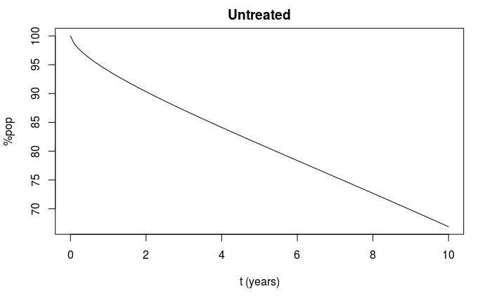

```r
n_t <- Vectorize(function(t) (1-W(t, params))*s(t))
curve(100*n_t(x), from=0, to=10, ylab="%pop", xlab="t (years)", main="Untreated")
```

And for completeness, secular death

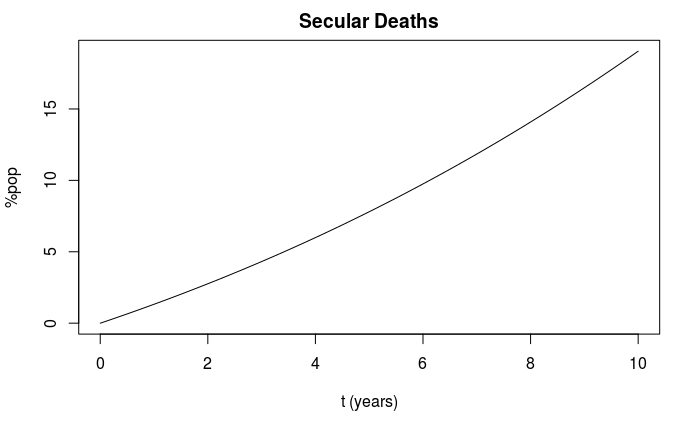

```r
sd_t <- Vectorize(function(t) 1-s(t))
curve(100*sd_t(x), from=0, to=10, ylab="%pop", xlab="t (years)", main="Secular Deaths")
```

## Cost / QALY integration

The costs depend directly upon risks of events, and these vary by the age category so while the sums above were informative, the useful ones are split between the three risk phases based on age of therapy. Let’s begin by breaking the primary treatment into occupancy by it’s three phases.

```r
f1_t <- Vectorize(function(t) s(t)*integrate(function(a) ifelse(t-a <= 0 | a > t, 0, w(t-a, params))*sf_a(a), lower=0, upper=30/365)$value)
f2_t <- Vectorize(function(t) s(t)*integrate(function(a) ifelse(t-a <= 0 | a > t, 0, w(t-a, params))*sf_a(a), lower=30/365, upper=1)$value)
f3_t <- Vectorize(function(t) s(t)*integrate(function(a) ifelse(t-a <= 0 | a >= t, 0, w(t-a, params))*sf_a(a), lower=1, upper=10)$value)
m1_t <- Vectorize(function(t) s(t)*integrate(function(a) ifelse(t-a <= 0 | a >= t, 0, w(t-a, params))*sm_a(a), lower=0, upper=30/365)$value)
m2_t <- Vectorize(function(t) s(t)*integrate(function(a) ifelse(t-a <= 0 | a >= t, 0, w(t-a, params))*sm_a(a), lower=30/365, upper=1)$value)
m3_t <- Vectorize(function(t) s(t)*integrate(function(a) ifelse(t-a <= 0 | a >= t, 0, w(t-a, params))*sm_a(a), lower=1, upper=10)$value)
par(mfrow=c(2,3))
curve(100*f1_t(x), from=0, to=10, ylab="%pop", xlab="t (years)", main="Prime <= 30d", ylim=c(0, 4))
curve(100*f2_t(x), from=0, to=10, ylab="%pop", xlab="t (years)", main="30d < Prime <= 1y",   ylim=c(0, 4))
```

```r
curve(100*f3_t(x), from=0, to=10, ylab="%pop", xlab="t (years)", main="Prime > 1 y",   ylim=c(0, 4))
curve(100*m1_t(x), from=0, to=10, ylab="%pop", xlab="t (years)", main="Maint <= 30d")
```

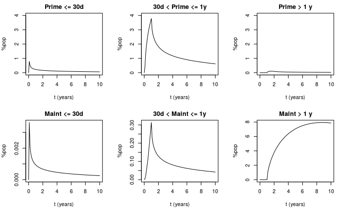

```r
curve(100*m2_t(x), from=0, to=10, ylab="%pop", xlab="t (years)", main="30d < Maint <= 1y")
curve(100*m3_t(x), from=0, to=10, ylab="%pop", xlab="t (years)", main="Maint > 1 y")
```

And the exposure in each category is the integral of these over the entire time. This only leaves consideration of permanent disutility to worry about.

```r
occupancy <- c(integrate(function(x) f1_t(x), lower=0, upper=10)$value,
               integrate(function(x) f2_t(x), lower=0, upper=10)$value,
               integrate(function(x) f3_t(x), lower=1, upper=10, subdivisions=2000)$value,
               integrate(function(x) m1_t(x), lower=0, upper=10)$value,
               integrate(function(x) m2_t(x), lower=0, upper=10)$value,
               integrate(function(x) m3_t(x), lower=1, upper=10, subdivisions=2000)$value)
cost <- c(params$chi_p, params$chi_m) * occupancy
cost
```

```
[1] 9.413379e-04 1.097916e-02 5.431806e-04 7.503630e-06 7.580656e-04 5.189615e-02
```

```r
tmp_qaly_loss <- c(params$rho_p, params$rho_m) * occupancy
tmp_qaly_loss
```

```
[1] 1.665068e-03 1.397721e-02 4.784949e-04 4.601896e-06 9.115339e-04 7.151537e-02
```

Permanent disutility is difficult now since this involves tracking events integrated to the end of time.

## Parameter Transform

# References

Kazi, DS, AM Garber, RU Shah, RA Dudley, MW Mell, C Rhee, S Moshkevich, DB Boothroyd, DK Owens, and MA Hlatky. 2014. “Cost-Effectiveness of Genotype-Guided and Dual Anti-Platelet Therapies in Acute Coronary Syndrome.” *Annals Internal Medicine* 160 (4): 221–32. doi:10.7326/M13-1999.

Webb, Glenn. 2008. *Structured Population Models in Biology and Epidemiology*. Edited by Pierre Magal and Shigui Ruan. Springer Berlin Heidelberg. doi:10.1007/978-3-540-78273-5_1.